# **NOTE:** Use File > Save a copy in Drive to make a copy before doing anything else

# Project 7: Data Exploration and Visualization

### Overview

In this project, you will apply data exploration and visualization techniques to a real-world dataset of your choice. You'll practice using pandas for data analysis and create meaningful visualizations to gain insights from your data. This project builds on your Python programming skills while introducing you to the exciting world of data science.

In [Lab7](https://colab.research.google.com/drive/15QvSh0csZaCU-OuuPIfpWx5wLDDjmqK4?usp=sharing), you explore the titanic dataset and you should use it as a sample and pick a dataset of your interest to do a similar data exploration and visualization.

### Project Objectives

- Find and select a dataset from a real-world data source
- Formulate a clear inquiry question based on your chosen dataset
- Perform exploratory data analysis using pandas functions
- Create at least two meaningful data visualizations
- Analyze your findings and answer your inquiry question
- Reflect on the insights gained through data exploration

### Data Sources

You can choose from various online data sources such as:

- [Kaggle](https://www.kaggle.com/datasets) - Wide variety of datasets
- [data.gov](https://www.data.gov/) - U.S. government data
- [Our World in Data](https://ourworldindata.org/) - Global development data
- [GitHub](https://github.com/datasets) - Curated datasets
- [Google Dataset Search](https://datasetsearch.research.google.com/) - Search for datasets
- Or any other reliable data source you find interesting

## Part 1: Dataset Selection and Initial Exploration

#### TODO Tasks:

1. Select Your Dataset: Choose a dataset that interests you. Make sure it has at least 100 rows and multiple columns with different data types (e.g., numerical, categorical, dates).

Please create either text or code cells in between the TODO tasks to do the work.

My chosen dataset: https://github.com/curran/data/blob/gh-pages/nyt/gun_sales/all-data.csv

2. Import Libraries: Import the necessary libraries (pandas, matplotlib, seaborn) at the beginning of your notebook by creating code cells below this text cell.

```python
# Importing pandas for data manipulation
import pandas as pd

# Importing matplotlib for data visualization
import matplotlib.pyplot as plt

# Importing seaborn for advanced data visualization
import seaborn as sns
```

3. Load Your Data: Load your chosen dataset using pandas and save it to a pandas dataframe. Please create a code cell below this text cell to do it.

```python
gun_df = pd.read_csv("https://raw.githubusercontent.com/curran/data/gh-pages/nyt/gun_sales/all-data.csv") #loading dataset and saving to pandas dataframe
```

4. Data Summary: Use the following functions to do inital exploration your dataset:
- info() - Display information about the dataset structure
- describe() - Show statistical summary of numerical columns
- head() - Display the first 5 rows (df.head())
- shape - Show the dimensions of the dataset (e.g. df.shape)
- columns - Get the column names (e.g. df.columns)

You may use 5 code cells below this text cell to accomplish it.

```python
gun_df.info() #analyzing info of dataset
```

```
<class 'pandas.core.frame.DataFrame'>
RangeIndex: 191 entries, 0 to 190
Data columns (total 17 columns):
 #   Column                               Non-Null Count  Dtype
---  ------                               --------------  -----
 0   year                                 191 non-null    int64
 1   month                                191 non-null    int64
 2   guns_total_per_1000                  191 non-null    float64
 3   guns_total                           191 non-null    int64
 4   guns_total_seas                      191 non-null    float64
 5   handgun_share                        191 non-null    float64
 6   longgun_share                        191 non-null    float64
 7   missouri                             191 non-null    float64
 8   maryland                             191 non-null    float64
 9   new_jersey                           191 non-null    float64
 10  district_of_columbia                 191 non-null    float64
 11  mississippi                          191 non-null    float64
 12  louisiana                            191 non-null    float64
 13  alabama                              191 non-null    float64
 14  texas                                191 non-null    float64
 15  georgia                              191 non-null    float64
 16  dc_handguns_per_100k_national_sales  191 non-null    float64
dtypes: float64(14), int64(3)
memory usage: 25.5 KB
```

```python
gun_df.describe() #describing data
```

|  | year | month | guns_total_per_1000 | guns_total | guns_total_seas | handgun_share | longgun_share | missouri | maryland | new_jersey | district_of_columbia | mississippi | louisiana | alabama | texas | georgia | dc_handguns_per_100k_national_sales |
| --- | --- | --- | --- | --- | --- | --- | --- | --- | --- | --- | --- | --- | --- | --- | --- | --- | --- |
| count | 191.000000 | 191.000000 | 191.000000 | 1.910000e+02 | 1.910000e+02 | 191.000000 | 191.000000 | 191.000000 | 191.000000 | 191.000000 | 191.000000 | 191.000000 | 191.000000 | 191.000000 | 191.000000 | 191.000000 | 191.000000 |
| mean | 2007.460733 | 6.471204 | 2.709848 | 8.241782e+05 | 8.255436e+05 | 0.383959 | 0.600619 | 3.115471 | 0.920183 | 0.606492 | 0.002204 | 1.749812 | 2.420890 | 2.975366 | 8.250958 | 2.683634 | 4.100524 |
| std | 4.601748 | 3.447037 | 0.692974 | 3.073732e+05 | 2.408114e+05 | 0.076203 | 0.084119 | 0.386864 | 0.386899 | 0.116055 | 0.003236 | 0.304201 | 0.214123 | 0.174888 | 0.595859 | 0.412296 | 4.073567 |
| min | 2000.000000 | 1.000000 | 1.983000 | 4.097420e+05 | 5.734940e+05 | 0.290200 | 0.392300 | 2.416000 | 0.636000 | 0.419000 | 0.000000 | 1.271000 | 1.849000 | 2.564000 | 7.013000 | 2.113000 | 0.000000 |
| 25% | 2003.500000 | 3.500000 | 2.222000 | 6.086745e+05 | 6.363697e+05 | 0.311400 | 0.547500 | 2.746000 | 0.757500 | 0.515500 | 0.000000 | 1.473500 | 2.282000 | 2.854500 | 7.791500 | 2.330000 | 0.500000 |
| 50% | 2007.000000 | 6.000000 | 2.440000 | 7.609010e+05 | 7.408464e+05 | 0.374800 | 0.610000 | 3.230000 | 0.844000 | 0.589000 | 0.001000 | 1.746000 | 2.393000 | 2.934000 | 8.345000 | 2.571000 | 2.100000 |
| 75% | 2011.000000 | 9.000000 | 3.256000 | 9.769635e+05 | 1.018934e+06 | 0.433350 | 0.681500 | 3.472000 | 1.006500 | 0.675500 | 0.004000 | 1.870000 | 2.511000 | 3.097500 | 8.657500 | 3.010500 | 7.700000 |
| max | 2015.000000 | 12.000000 | 6.388000 | 2.388128e+06 | 2.014801e+06 | 0.575200 | 0.703000 | 3.944000 | 5.443000 | 1.141000 | 0.034000 | 2.473000 | 3.473000 | 3.470000 | 10.512000 | 4.142000 | 15.600000 |

```python
gun_df.head() # seeing first few data rows
```

|  | year | month | guns_total_per_1000 | guns_total | guns_total_seas | handgun_share | longgun_share | missouri | maryland | new_jersey | district_of_columbia | mississippi | louisiana | alabama | texas | georgia | dc_handguns_per_100k_national_sales |
| --- | --- | --- | --- | --- | --- | --- | --- | --- | --- | --- | --- | --- | --- | --- | --- | --- | --- |
| 0 | 2000 | 1 | 2.332 | 574951 | 655088.710686 | 0.3183 | 0.6749 | 2.710 | 0.636 | 0.469 | 0.0 | 2.391 | 2.506 | 3.140 | 8.164 | 3.075 | 2.1 |
| 1 | 2000 | 2 | 2.344 | 649111 | 658925.860865 | 0.3178 | 0.6755 | 2.728 | 0.642 | 0.475 | 0.0 | 2.394 | 2.493 | 3.122 | 8.274 | 3.045 | 0.5 |
| 2 | 2000 | 3 | 2.335 | 664622 | 657021.995132 | 0.3202 | 0.6728 | 2.668 | 0.644 | 0.493 | 0.0 | 2.339 | 2.447 | 3.071 | 8.443 | 3.067 | 1.0 |
| 3 | 2000 | 4 | 2.342 | 552965 | 659698.475053 | 0.3188 | 0.6741 | 2.743 | 0.687 | 0.517 | 0.0 | 2.422 | 2.601 | 3.188 | 8.451 | 3.171 | 1.5 |
| 4 | 2000 | 5 | 2.297 | 467712 | 647409.449153 | 0.3148 | 0.6775 | 2.739 | 0.678 | 0.525 | 0.0 | 2.453 | 2.538 | 3.179 | 8.506 | 3.092 | 1.1 |

```python
gun_df.shape #identifying data shape
```

```
(191, 17)
```

```python
gun_df.columns #identifying columns in data
```

```
Index(['year', 'month', 'guns_total_per_1000', 'guns_total', 'guns_total_seas',
       'handgun_share', 'longgun_share', 'missouri', 'maryland', 'new_jersey',
       'district_of_columbia', 'mississippi', 'louisiana', 'alabama', 'texas',
       'georgia', 'dc_handguns_per_100k_national_sales'],
      dtype='object')
```

5. Inquiry Question: Write a clear, specific question that you want to answer using your dataset by creating a text cell below and **write the question in bold please.**

For example:

- "How has the average temperature changed in major cities over the past decade?"
- "What factors are most strongly correlated with housing prices?"
- "Is there a relationship between education level and income?"

**When are the seasonal peaks of number of gun sales nationwide?**

## Part 2: Data Visualization and Analysis

#### TODO Tasks:

1. Data Cleaning (if necessary): Check for and handle any missing values, duplicates, or data quality issues.

**NOTE: This could be a daunting task even for seasoned data scientists. My suggestion is to use a dataset that is already clean if you can for the purpose of completing this assignment in a week.**

Examples:

- Checking for missing values: df.isnull().sum()
- Dropping rows with any missing values: df.dropna(inplace=True)
- Dropping columns with all missing values: df.dropna(axis=1, how='all', inplace=True)
- Removing duplicate row: df.drop_duplicates(inplace=True)

```python
# prompt: Check for and handle any missing values, duplicates, or data quality issues.

# Check for missing values
print("Missing values per column:")
print(gun_df.isnull().sum())

# Check for duplicate rows
print("\nNumber of duplicate rows:")
print(gun_df.duplicated().sum())

# Handle missing values (example: dropping rows with any missing values - choose appropriate strategy for your data)
# For this dataset, the columns seem clean. If there were missing values, you might do something like:
# gun_df.dropna(inplace=True)

# Handle duplicate rows (example: dropping duplicate rows)
if gun_df.duplicated().sum() > 0:
    print("\nDropping duplicate rows...")
    #gun_df.drop_duplicates(inplace=True)
    print("Number of duplicate rows after dropping:", gun_df.duplicated().sum())

# For this dataset, it seems relatively clean based on the initial inspection.
# Data quality issues often require domain knowledge and deeper analysis depending on the specific dataset and columns.
# For instance, you might check for outliers in numerical columns or inconsistent formats in categorical columns.
# As the prompt suggests focusing on a clean dataset for this project, we will proceed assuming the data is of sufficient quality for exploration and visualization.
```

```
Missing values per column:
year                                   0
month                                  0
guns_total_per_1000                    0
guns_total                             0
guns_total_seas                        0
handgun_share                          0
longgun_share                          0
missouri                               0
maryland                               0
new_jersey                             0
district_of_columbia                   0
mississippi                            0
louisiana                              0
alabama                                0
texas                                  0
georgia                                0
dc_handguns_per_100k_national_sales    0
dtype: int64

Number of duplicate rows:
0
```

2. Create Visualizations: Create at least 2 different types of visualizations that help answer your research question. Choose from:
- Bar charts
- Line plots
- Scatter plots
- Histograms
- Box plots
- Heatmaps
- Any other appropriate visualization

[figure not shown]

```
Peak Quarter for Gun Sales per Year:
    year  quarter  guns_total
3   2000        4     2638020
7   2001        4     2789705
11  2002        4     2406629
15  2003        4     2410528
19  2004        4     2536434
23  2005        4     2704857
27  2006        4     2709968
31  2007        4     2648132
35  2008        4     3450212
36  2009        1     2868994
43  2010        4     3046269
47  2011        4     3606406
51  2012        4     5119876
52  2013        1     5152501
59  2014        4     4266686
60  2015        1     3582420
```

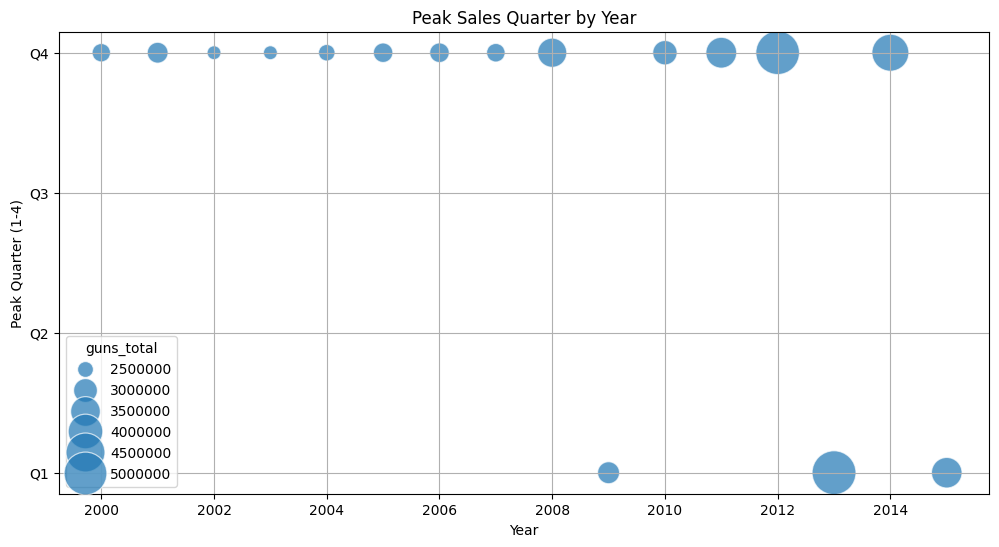

[figure not shown]

```python
# prompt: plot a line plot , x axis is quarterly time in years and y axis is guns_total. any changes sgould be made to a copy of df. the data should be grouped by quarter.
# gun_df_copy['day'] = 1
# gun_df_copy['datetime'] = pd.to_datetime(gun_df_copy[['year', 'month', 'day']])
# # Extract the quarter and year
# gun_df_copy['year_quarter'] = gun_df_copy['datetime'].dt.to_period('Q')
# When does it peak per year. Make sure your visualizations are clear and informative by:
# Adding appropriate titles
# Labeling axes
# Using colors effectively
# Adding legends when necessary

# Make a copy to avoid modifying the original DataFrame
gun_df_copy = gun_df.copy()
gun_df_copy['day'] = 1
gun_df_copy['datetime'] = pd.to_datetime(gun_df_copy[['year', 'month', 'day']])
# Extract the quarter and year
gun_df_copy['year_quarter'] = gun_df_copy['datetime'].dt.to_period('Q')
gun_df_copy['year'] = gun_df_copy['datetime'].dt.year
gun_df_copy['quarter'] = gun_df_copy['datetime'].dt.quarter

# Group by year and quarter and sum the total gun sales
quarterly_sales = gun_df_copy.groupby('year_quarter')['guns_total'].sum().reset_index()

# Convert the 'year_quarter' period to string for plotting
quarterly_sales['year_quarter_str'] = quarterly_sales['year_quarter'].astype(str)

# Plotting the line plot for quarterly gun sales
plt.figure(figsize=(15, 7))
sns.lineplot(data=quarterly_sales, x='year_quarter_str', y='guns_total')
plt.title('Total Gun Sales by Quarter (1998-2016)')
plt.xlabel('Year-Quarter')
plt.ylabel('Total Gun Sales')
plt.xticks(rotation=90) # Rotate x-axis labels for better readability
plt.grid(True)
plt.tight_layout() # Adjust layout to prevent labels overlapping
plt.show()

# Identify the peak quarter for each year
# Group by year and find the quarter with the maximum sales
peak_quarter_per_year = gun_df_copy.groupby(['year', 'quarter'])['guns_total'].sum().reset_index()
peak_quarter_per_year = peak_quarter_per_year.loc[peak_quarter_per_year.groupby('year')['guns_total'].idxmax()]

print("\nPeak Quarter for Gun Sales per Year:")
print(peak_quarter_per_year) #checking values for correctness

# Visualize peak quarter per year (Optional - adding another visualization)
plt.figure(figsize=(12, 6))
sns.scatterplot(data=peak_quarter_per_year, x='year', y='quarter', size='guns_total', sizes=(100, 1000), alpha=0.7)
plt.title('Peak Sales Quarter by Year')
plt.xlabel('Year')
plt.ylabel('Peak Quarter (1-4)')
plt.yticks([1, 2, 3, 4],  ['Q1', 'Q2', 'Q3', 'Q4'])
plt.grid(True)
plt.show()

# Plot total sales grouped by quarter across all years to see the overall seasonal trend
quarterly_sales_overall = gun_df_copy.groupby('quarter')['guns_total'].sum().reset_index()

plt.figure(figsize=(8, 5)) #creating plot and designing for visibility
sns.barplot(data=quarterly_sales_overall, x='quarter', y='guns_total', palette='viridis')
plt.title('Total Gun Sales by Quarter (Overall 1998-2016)')
plt.xlabel('Quarter')
plt.ylabel('Total Gun Sales')
plt.xticks([0, 1, 2, 3], ['Q1', 'Q2', 'Q3', 'Q4'])
plt.show()
```

3. Customize Your Plots: Make sure your visualizations are clear and informative by:
- Adding appropriate titles
- Labeling axes
- Using colors effectively
- Adding legends when necessary

Please create code cells below this to create your visualizations.

4. Analysis: Write 1-2 paragraphs discussing:
- Whether your research question can be answered with the available data
- What insights you discovered through your visualizations
- Any unexpected or interesting findings
- Limitations of your analysis
- Suggestions for further investigation

## NOTE: If you use a local dataset, you MUST submit the dataset along with your notebook to get credit.

- Download your notebook as CS110_Project7.ipynb
- Ensure all TODO tasks are completed
- Make sure your code runs without errors
- Include clear comments explaining your work
- Submit the notebook file

## Grading Criteria (4 points)

- Dataset Selection: Appropriate choice of dataset with sufficient complexity
- Inquiry Question: Clear, specific, and answerable with the chosen data
- Data Exploration: Proper use of pandas functions for initial analysis
- Visualizations: At least 2 clear, well-formatted, and relevant plots
- Analysis: Thoughtful interpretation of findings and answer to research question
- Code Quality: Clean, commented, and well-organized code

Remember: The goal is not just to create visualizations, but to use them to gain meaningful insights about your data. Think like a data scientist and let your curiosity guide your exploration!